© Bản quyền thuộc về Quantopian Inc.  
© Bản quyền sửa đổi thuộc về AI Cafe¹  
Giấy phép [Creative Commons Attribution 4.0](https://creativecommons.org/licenses/by/4.0/legalcode).  
[Khuyến cáo](https://aicafe.one/khuyen-cao/)

# Bộ lọc Kalman

By Evgenia "Jenny" Nitishinskaya, Dr. Aidan O'Mahony, and Delaney Granizo-Mackenzie. Algorithms by David Edwards.

Kalman Filter Beta Estimation Example from [Dr. Aidan O'Mahony's blog.](http://www.thealgoengineer.com/2014/online_linear_regression_kalman_filter/)

Edited by AI Cafe¹

Kalman filter là một thuật toán sử dụng các quan sát nhiễu của một hệ thống theo thời gian để ước lượng các tham số của hệ thống (một số trong số đó không thể quan sát được) và dự đoán các quan sát trong tương lai. Tại mỗi bước thời gian, nó đưa ra một dự đoán, nhận một phép đo và cập nhật bản thân dựa trên sự so sánh giữa dự đoán và phép đo.

Thuật toán được thực hiện như sau:

1. Nhận đầu vào một mô hình toán học của hệ thống, tức là:
   - ma trận chuyển tiếp, cho biết cách hệ thống tiến triển từ trạng thái này sang trạng thái khác. Ví dụ, nếu chúng ta đang mô phỏng chuyển động của một chiếc xe, thì các giá trị tiếp theo của vị trí và vận tốc có thể được tính toán từ các giá trị trước đó bằng cách sử dụng các phương trình động học. Hoặc, nếu chúng ta có một hệ thống tương đối ổn định, chúng ta có thể mô hình hóa sự tiến triển của nó như một chuyển động ngẫu nhiên. Nếu bạn muốn tìm hiểu về các bộ lọc Kalman, hãy lưu ý rằng ma trận này thường được gọi là $A$.
   - ma trận quan sát, cho biết phép đo tiếp theo mà chúng ta nên mong đợi dựa trên trạng thái dự đoán tiếp theo. Nếu chúng ta đang đo vị trí của chiếc xe, chúng ta chỉ cần trích xuất các giá trị vị trí được lưu trong trạng thái. Ví dụ phức tạp hơn, hãy xem xét việc ước lượng một mô hình hồi quy tuyến tính cho dữ liệu. Khi đó, trạng thái của chúng ta là các hệ số của mô hình, và chúng ta có thể dự đoán phép đo tiếp theo từ phương trình tuyến tính. Điều này được ký hiệu là $H$.
   - bất kỳ yếu tố kiểm soát nào ảnh hưởng đến các chuyển tiếp trạng thái nhưng không phải là một phần của các phép đo. Ví dụ, nếu chiếc xe của chúng ta đang rơi, trọng lực sẽ là một yếu tố kiểm soát. Nếu nhiễu không có trung bình bằng 0, nó nên được dịch chuyển và độ lệch được đưa vào các yếu tố kiểm soát. Các yếu tố kiểm soát được tóm tắt trong một ma trận $B$ với vector kiểm soát thay đổi theo thời gian $u_t$, cung cấp độ lệch $Bu_t$.
   - ma trận hiệp phương sai của nhiễu chuyển tiếp (tức là nhiễu trong sự tiến triển của hệ thống) và nhiễu đo, được ký hiệu là $Q$ và $R$, tương ứng.
2. Nhận đầu vào một ước lượng ban đầu của trạng thái của hệ thống và sai số của ước lượng, $\mu_0$ và $\sigma_0$.
3. Tại mỗi bước:
   - ước lượng trạng thái hiện tại của hệ thống $x_t$ sử dụng ma trận chuyển tiếp
   - nhận các phép đo mới $z_t$
   - sử dụng xác suất có điều kiện của các phép đo dựa trên trạng thái, lưu ý đến những bất định của phép đo và ước lượng trạng thái, để cập nhật trạng thái hiện tại ước tính của hệ thống $x_t$ và ma trận hiệp phương sai của ước lượng $P_t$.

[Hình ảnh này](https://upload.wikimedia.org/wikipedia/commons/a/a5/Basic_concept_of_Kalman_filtering.svg) minh họa quy trình mà thuật toán thực hiện.

Để thuật toán theo dõi các hiệp phương sai của các ước lượng của nó là rất quan trọng. Bằng cách này, nó có thể đưa ra một kết quả tinh vi hơn là chỉ một giá trị điểm khi chúng ta yêu cầu nó, và nó có thể sử dụng sự tự tin của mình để quyết định mức độ bị ảnh hưởng bởi các phép đo mới trong quá trình cập nhật. Càng chắc chắn về ước lượng của nó về trạng thái, nó sẽ càng hoài nghi về các phép đo không đồng ý với trạng thái.

Mặc định, các sai số được giả định là phân phối chuẩn, và giả định này cho phép thuật toán tính toán các khoảng tin cậy chính xác. Tuy nhiên, nó có thể được thực hiện cho các sai số không chuẩn.

LƯU Ý: Bài giảng này sử dụng mô-đun `pykalman` mà không được cài đặt mặc định. Để cài đặt nó, hãy chạy cell sau:

```python
!pip install -q git+https://github.com/pykalman/pykalman@ea0965b6ddaabd424d18518f8f7d2f165a0a65ad
```

```
  Installing build dependencies ... done
  Getting requirements to build wheel ... done
  Preparing metadata (pyproject.toml) ... done
```

```python
# Import a Kalman filter and other useful libraries
from pykalman import KalmanFilter
import numpy as np
import pandas as pd
import matplotlib.pyplot as plt
import matplotlib as mpl
from numpy import poly1d
```

## Ví dụ: quả bóng rơi

Hãy tưởng tượng rằng chúng ta có một quả bóng đang rơi mà chuyển động của nó được theo dõi bằng một camera. Trạng thái của quả bóng bao gồm vị trí và vận tốc của nó. Chúng ta biết rằng chúng ta có mối quan hệ $x_t = x_{t-1} + v_{t-1}\tau - \frac{1}{2} g \tau^2$, trong đó $\tau$ là thời gian (tính bằng giây) đã trôi qua giữa $t-1$ và $t$, và $g$ là gia tốc trọng trường. Trong khi đó, camera của chúng ta có thể cho chúng ta biết vị trí của quả bóng mỗi giây, nhưng chúng ta biết từ nhà sản xuất rằng độ chính xác của camera, được chuyển thành vị trí của quả bóng, có độ biến thiên trong ước lượng vị trí khoảng 3 mét.

Để sử dụng bộ lọc Kalman, chúng ta cần cung cấp cho nó các ma trận chuyển tiếp và quan sát, các ma trận hiệp phương sai chuyển tiếp và quan sát, cũng như trạng thái ban đầu. Trạng thái của hệ thống là (vị trí, vận tốc), vì vậy nó tuân theo ma trận chuyển tiếp $$ \left( \begin{array}{cc} 1 & \tau \\ 0 & 1 \end{array} \right) $$

```python
tau = 0.1

# Set up the filter
kf = KalmanFilter(n_dim_obs=1, n_dim_state=2, # position is 1-dimensional, (x,v) is 2-dimensional
                  initial_state_mean=[30,10],
                  initial_state_covariance=np.eye(2),
                  transition_matrices=[[1,tau], [0,1]],
                  observation_matrices=[[1,0]],
                  observation_covariance=3,
                  transition_covariance=np.zeros((2,2)),
                  transition_offsets=[-4.9*tau**2, -9.8*tau])
```

```python
# Create a simulation of a ball falling for 40 units of time (each of length tau)
times = np.arange(40)
actual = -4.9*tau**2*times**2

# Simulate the noisy camera data
sim = actual + 3*np.random.randn(40)

# Run filter on camera data
state_means, state_covs = kf.filter(sim)
```

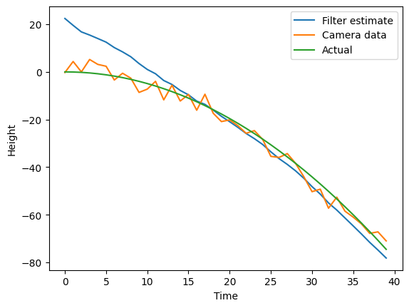

```python
plt.plot(times, state_means[:,0])
plt.plot(times, sim)
plt.plot(times, actual)
plt.legend(['Filter estimate', 'Camera data', 'Actual'])
plt.xlabel('Time')
plt.ylabel('Height');
```

Tại mỗi thời điểm, chúng ta vẽ ước lượng trạng thái *sau* khi đã tính đến phép đo gần đây nhất, đó là lý do tại sao chúng ta không ở vị trí 30 vào thời điểm 0. Sự chú ý của bộ lọc đối với các phép đo cho phép nó điều chỉnh cho trạng thái ban đầu không chính xác mà chúng ta đã cung cấp. Sau đó, bằng cách đánh giá mô hình của nó và kiến thức về các quy luật vật lý so với các phép đo mới, nó có khả năng lọc ra phần lớn nhiễu trong dữ liệu từ camera. Trong khi đó, độ tin cậy vào ước lượng tăng lên theo thời gian, như được thể hiện trong biểu đồ dưới đây:

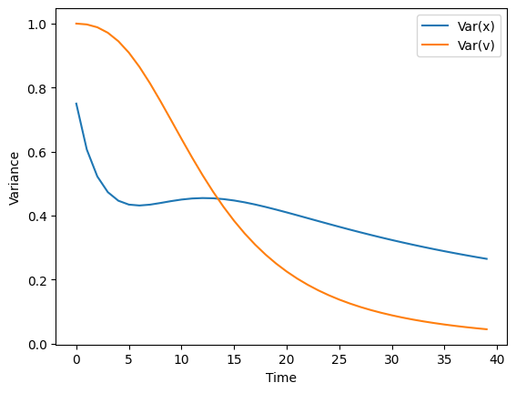

```python
# Plot variances of x and v, extracting the appropriate values from the covariance matrix
plt.plot(times, state_covs[:,0,0])
plt.plot(times, state_covs[:,1,1])
plt.legend(['Var(x)', 'Var(v)'])
plt.ylabel('Variance')
plt.xlabel('Time');
```

Bộ lọc Kalman cũng có thể thực hiện *làm mượt*, điều này có nghĩa là nó tiếp nhận tất cả dữ liệu đầu vào cùng một lúc và sau đó xây dựng ước lượng tốt nhất cho trạng thái của hệ thống trong mỗi khoảng thời gian sau này. Tức là, nó không cung cấp ước lượng trực tuyến, mà thay vào đó sử dụng tất cả dữ liệu để ước lượng trạng thái lịch sử, điều này rất hữu ích nếu chúng ta chỉ muốn sử dụng dữ liệu sau khi đã thu thập tất cả.

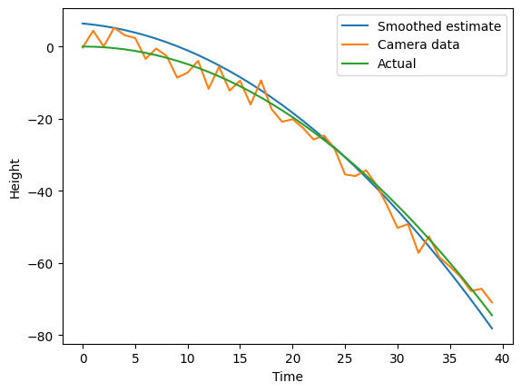

```python
# Use smoothing to estimate what the state of the system has been
smoothed_state_means, _ = kf.smooth(sim)

# Plot results
plt.plot(times, smoothed_state_means[:,0])
plt.plot(times, sim)
plt.plot(times, actual)
plt.legend(['Smoothed estimate', 'Camera data', 'Actual'])
plt.xlabel('Time')
plt.ylabel('Height');
```

## Ví dụ: trung bình động

Vì bộ lọc Kalman cập nhật ước lượng của nó tại mỗi bước thời gian và có xu hướng cân nhắc các quan sát gần đây hơn là các quan sát cũ hơn, một ứng dụng đặc biệt hữu ích là ước lượng các tham số động của dữ liệu. Khi sử dụng bộ lọc Kalman, không có độ dài cửa sổ nào mà chúng ta cần chỉ định. Điều này rất hữu ích cho việc tính toán trung bình động nếu đó là điều chúng ta quan tâm, hoặc để làm mượt các ước lượng của các đại lượng khác. Chẳng hạn, nếu chúng ta đã tính toán tỷ lệ Sharpe động, chúng ta có thể làm mượt nó bằng cách sử dụng bộ lọc Kalman.

Dưới đây, chúng ta sẽ sử dụng cả bộ lọc Kalman và trung bình động n ngày để ước lượng trung bình động của một tập dữ liệu. Chúng ta hy vọng rằng trung bình mô tả tốt các quan sát của chúng ta, vì vậy nó không nên thay đổi quá nhiều khi chúng ta thêm một quan sát; do đó, chúng ta giả định rằng nó phát triển như một bước đi ngẫu nhiên với một sai số nhỏ. Trung bình là dự đoán của mô hình cho trung bình của phân phối từ đó các phép đo được lấy ra, vì vậy dự đoán của chúng ta cho giá trị tiếp theo đơn giản bằng với ước lượng của chúng ta về trung bình. Chúng ta giả định rằng các quan sát có phương sai 1 xung quanh trung bình động, vì không có ước lượng tốt hơn. Dự đoán ban đầu của chúng ta cho trung bình là 0, nhưng bộ lọc nhanh chóng nhận ra rằng điều đó là sai và điều chỉnh.

```python
# Cài thư viện lấy dữ liệu miễn phí
!curl -fsSLO https://raw.githubusercontent.com/algo-stocks/data/master/data.py
```

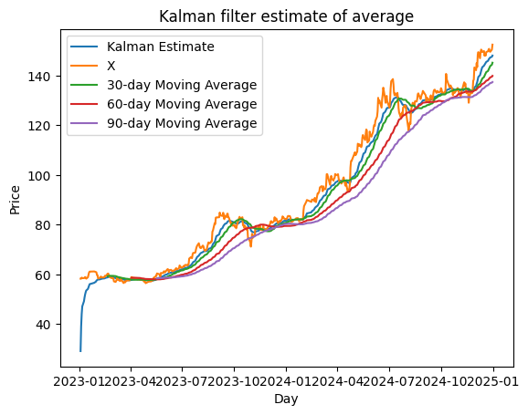

```python
from data import get_prices

start = '2023-01-01'
end = '2025-01-01'

x = get_prices('FPT', start_date=start, end_date=end).FPT

# Construct a Kalman filter
kf = KalmanFilter(transition_matrices = [1],
                  observation_matrices = [1],
                  initial_state_mean = 0,
                  initial_state_covariance = 1,
                  observation_covariance=1,
                  transition_covariance=.01)

# Use the observed values of the price to get a rolling mean
state_means, _ = kf.filter(x.values)
state_means = pd.Series(state_means.flatten(), index=x.index)

# Compute the rolling mean with various lookback windows
mean30 = x.rolling(window = 30).mean()
mean60 = x.rolling(window = 60).mean()
mean90 = x.rolling(window = 90).mean()

# Plot original data and estimated mean
plt.plot(state_means)
plt.plot(x)
plt.plot(mean30)
plt.plot(mean60)
plt.plot(mean90)
plt.title('Kalman filter estimate of average')
plt.legend(['Kalman Estimate', 'X', '30-day Moving Average', '60-day Moving Average','90-day Moving Average'])
plt.xlabel('Day')
plt.ylabel('Price');
```

Điều này hơi khó nhìn, vì vậy chúng ta sẽ vẽ một phần của đồ thị.

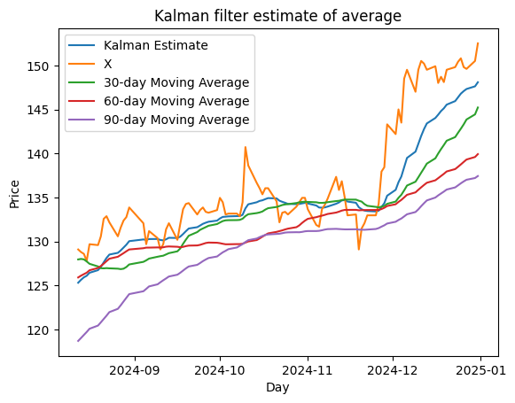

```python
plt.plot(state_means[-100:])
plt.plot(x[-100:])
plt.plot(mean30[-100:])
plt.plot(mean60[-100:])
plt.plot(mean90[-100:])
plt.title('Kalman filter estimate of average')
plt.legend(['Kalman Estimate', 'X', '30-day Moving Average', '60-day Moving Average','90-day Moving Average'])
plt.xlabel('Day')
plt.ylabel('Price');
```

Lợi thế của bộ lọc Kalman là chúng ta không cần phải chọn chiều dài cửa sổ, do đó chúng ta gặp ít rủi ro hơn trong việc quá khớp (overfitting). Tuy nhiên, chúng ta vẫn có thể gặp phải vấn đề quá khớp với một số tham số khởi tạo cho bộ lọc, nhưng những tham số đó dễ dàng được xác định một cách khách quan hơn. Chúng ta không thể loại bỏ hoàn toàn việc quá khớp, nhưng bộ lọc Kalman chính xác hơn so với trung bình động và thường thì tốt hơn.

## Ví dụ: hồi quy tuyến tính

Hãy thử sử dụng bộ lọc Kalman để tìm các đường hồi quy tuyến tính cho một tập dữ liệu. Chúng ta sẽ so sánh giá cổ phiếu với chỉ số VNINDEX, vì vậy kết quả sẽ là một loại alpha và beta liên tục cho cổ phiếu, trong đó $\alpha$ và $\beta$ là các tham số của phương trình hồi quy tuyến tính $$ y_t \approx \alpha + \beta x_t $$

Dưới đây, chúng ta sử dụng màu sắc để chỉ ra các ngày mà các điểm dữ liệu $(x_t, y_t)$ tương ứng.

```python
# Load pricing data

start = '2022-01-01'
end = '2025-01-01'

prices = get_prices('FPT', 'VNINDEX', start_date=start, end_date=end).ffill()

y = prices['FPT']
x = prices['VNINDEX']
```

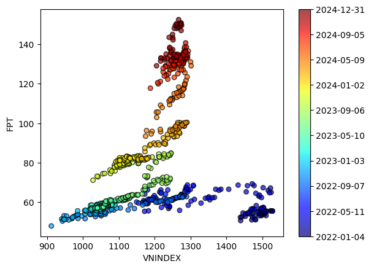

```python
# Plot data and use colormap to indicate the date each point corresponds to
cm = plt.get_cmap('jet')
colors = np.linspace(0.1, 1, len(x))
sc = plt.scatter(x, y, s=30, c=colors, cmap=cm, edgecolor='k', alpha=0.7)
cb = plt.colorbar(sc)
cb.ax.yaxis.set_major_locator(mpl.ticker.FixedLocator(cb.ax.get_yticks().tolist()))
cb.ax.set_yticklabels([str(p.date()) for p in x[::len(x)//9].index])
plt.xlabel('VNINDEX')
plt.ylabel('FPT');
```

Hãy cùng tìm hiểu các đầu vào cho bộ lọc Kalman của chúng ta. Chúng ta sẽ nói rằng trạng thái của hệ thống của chúng ta là đường thẳng mà các quan sát đang theo, với các tham số $\alpha$ và $\beta$. Dự đoán ban đầu của chúng ta cho các tham số này là (0,0), với ma trận hiệp phương sai (mô tả sai số của dự đoán của chúng ta) là tất cả các giá trị bằng một. Như trong ví dụ về trung bình động, chúng ta giả định rằng các tham số của chúng ta theo một bước đi ngẫu nhiên (ma trận chuyển tiếp là ma trận đơn vị) với một hạng mục sai số nhỏ (hiệp phương sai chuyển tiếp là một số nhỏ nhân với ma trận đơn vị).

Để chuyển từ trạng thái của hệ thống sang một quan sát, chúng ta nhân điểm trạng thái $(\beta, \alpha)$ với $(x_i, 1)$ để có $\beta x_i + \alpha \approx y_i$, vì vậy ma trận quan sát của chúng ta chỉ là một cột của các số 1 gắn liền với $x$. Chúng ta giả định rằng phương sai của các quan sát $y$ là 2. Bây giờ chúng ta đã sẵn sàng sử dụng các quan sát của $y$ để phát triển các ước lượng của các tham số $\alpha$ và $\beta$.

```python
delta = 1e-3
trans_cov = delta / (1 - delta) * np.eye(2) # How much random walk wiggles
obs_mat = np.expand_dims(np.vstack([[x], [np.ones(len(x))]]).T, axis=1)

kf = KalmanFilter(n_dim_obs=1, n_dim_state=2, # y is 1-dimensional, (alpha, beta) is 2-dimensional
                  initial_state_mean=[0,0],
                  initial_state_covariance=np.ones((2, 2)),
                  transition_matrices=np.eye(2),
                  observation_matrices=obs_mat,
                  observation_covariance=2,
                  transition_covariance=trans_cov)
```

```python
# Use the observations y to get running estimates and errors for the state parameters
state_means, state_covs = kf.filter(y.values)
```

Dưới đây, chúng ta vẽ biểu đồ các giá trị trung bình - tức là, ước lượng tốt nhất của chúng ta - về $\alpha$ và $\beta$ theo thời gian.

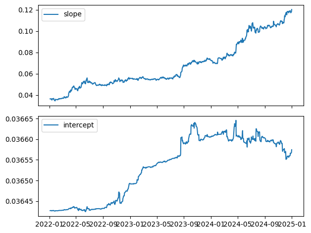

```python
_, axarr = plt.subplots(2, sharex=True)
axarr[0].plot(x.index, state_means[:,0], label='slope')
axarr[0].legend()
axarr[1].plot(x.index, state_means[:,1], label='intercept')
axarr[1].legend()
plt.tight_layout();
```

Lưu ý rằng các tham số dao động nhiều qua các khoảng thời gian dài. Nếu chúng ta dựa vào một thuật toán giao dịch dựa trên điều này, chẳng hạn như một cái gì đó liên quan đến việc phòng hộ beta, thì việc có được ước lượng tốt nhất và cập nhật nhất về beta là rất quan trọng. Để hình dung cách mà hệ thống tiến triển theo thời gian, chúng tôi vẽ biểu đồ mỗi trạng thái thứ năm (mô hình tuyến tính) bên dưới. Để so sánh, màu đen là đường được trả về bằng cách sử dụng hồi quy bình phương nhỏ nhất trên toàn bộ tập dữ liệu, điều này rất khác biệt.

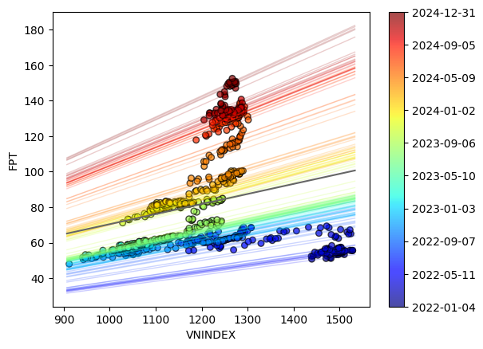

```python
# Plot data points using colormap
sc = plt.scatter(x, y, s=30, c=colors, cmap=cm, edgecolor='k', alpha=0.7)
cb = plt.colorbar(sc)
cb.ax.yaxis.set_major_locator(mpl.ticker.FixedLocator(cb.ax.get_yticks().tolist()))
cb.ax.set_yticklabels([str(p.date()) for p in x[::len(x)//9].index])

# Plot every fifth line
step = 5
xi = np.linspace(x.min()-5, x.max()+5, 2)
colors_l = np.linspace(0.1, 1, len(state_means[::step]))
for i, beta in enumerate(state_means[::step]):
    plt.plot(xi, beta[0] * xi + beta[1], alpha=.2, lw=1, c=cm(colors_l[i]))

# Plot the OLS regression line
plt.plot(xi, poly1d(np.polyfit(x, y, 1))(xi), '0.4')

# Label axes
plt.xlabel('VNINDEX')
plt.ylabel('FPT');
```

Lưu ý rằng mặc dù tất cả các ước lượng trạng thái đều xem xét tất cả các quan sát trước đó, nhưng chúng phù hợp với dữ liệu gần đây hơn là dữ liệu cũ. Điều này cho phép bộ lọc thích ứng với các thay đổi cấu trúc trong dữ liệu theo thời gian.

Bây giờ, phần lớn thời gian chúng ta quan tâm đến sự tương quan trong lợi nhuận nhiều hơn là sự tương quan trong giá cả, vì vậy hãy nhanh chóng sử dụng cùng một cấu trúc hồi quy tuyến tính trên dữ liệu lợi nhuận:

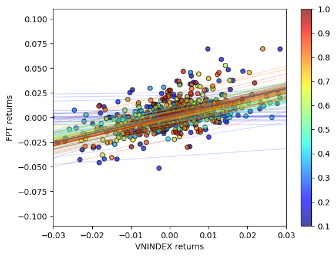

```python
# Get returns from pricing data
x_r = x.pct_change()[1:]
y_r = y.pct_change()[1:]

# Run Kalman filter on returns data
delta_r = 1e-2
trans_cov_r = delta_r / (1 - delta_r) * np.eye(2) # How much random walk wiggles
obs_mat_r = np.expand_dims(np.vstack([[x_r], [np.ones(len(x_r))]]).T, axis=1)
kf_r = KalmanFilter(n_dim_obs=1, n_dim_state=2, # y_r is 1-dimensional, (alpha, beta) is 2-dimensional
                  initial_state_mean=[0,0],
                  initial_state_covariance=np.ones((2, 2)),
                  transition_matrices=np.eye(2),
                  observation_matrices=obs_mat_r,
                  observation_covariance=.01,
                  transition_covariance=trans_cov_r)
state_means_r, _ = kf_r.filter(y_r.values)

# Plot data points using colormap
colors_r = np.linspace(0.1, 1, len(x_r))
sc = plt.scatter(x_r, y_r, s=30, c=colors_r, cmap=cm, edgecolor='k', alpha=0.7)
cb = plt.colorbar(sc)
cb.ax.yaxis.set_major_locator(mpl.ticker.FixedLocator(cb.ax.get_yticks().tolist()))

# Plot every fifth line
step = 5
xi = np.linspace(x_r.min()-4, x_r.max()+4, 2)
colors_l = np.linspace(0.1, 1, len(state_means_r[::step]))
for i, beta in enumerate(state_means_r[::step]):
    plt.plot(xi, beta[0] * xi + beta[1], alpha=.2, lw=1, c=cm(colors_l[i]))

# Plot the OLS regression line
plt.plot(xi, poly1d(np.polyfit(x_r, y_r, 1))(xi), '0.4')

# Adjust axes for visibility
plt.axis([-0.03,0.03,-0.11, 0.11])

# Label axes
plt.xlabel('VNINDEX returns')
plt.ylabel('FPT returns');
```

Mặc dù dữ liệu thô ở đây bị rối rắm hơn nhiều, nhưng chúng ta có thể thấy đường hồi quy đang phát triển, thậm chí có lúc vượt qua đường hồi quy OLS.

## Tổng quát

Chúng ta có thể sử dụng bộ lọc Kalman để mô hình hóa các hàm chuyển tiếp và quan sát phi tuyến. Để làm điều này, có các bộ lọc Kalman mở rộng và có chọn lọc (unscented), trong đó bộ lọc unscented được bao gồm trong `pykalman`. Những bộ lọc này thậm chí có thể mô hình hóa các tình huống mà nhiễu không phải là cộng dồn (ví dụ, nơi nhiễu tỷ lệ với kích thước của phép đo). Chúng ta cũng có thể chỉ định các lỗi phi Gauss; điều này rất hữu ích trong dữ liệu tài chính, thường có phân phối đuôi nặng.

Ngoài ra còn có các thuật toán để suy diễn một số tham số đầu vào, chẳng hạn như ma trận hiệp phương sai và trạng thái ban đầu, từ một tập dữ liệu ban đầu. Điều này có thể được thực hiện với phương thức `pykalman.em()`.

*Lưu ý: Tài liệu này mang tính chất chia sẻ kiến thức khoa học dữ liệu. Các mã chứng khoán xuất hiện trong tài liệu chỉ mang tính chất minh hoạ, không khuyến nghị đầu tư. Chúng tôi không chịu trách nhiệm trước mọi rủi ro nào do sử dụng tài liệu này.*